# sibylfs.io

Tom Ridge

2015-09-21  
(with Thomas Tuerk, David Sheets, Andrea Giugliano, Anil Madhavapeddy, Peter Sewell;  
talk at departmental Industrial Advisory Board; 20 mins talk+? mins qus)

# The problem

# The problem: specifications

- Everyone knows specifications are important; how else do you know what something is supposed to do?
- So, where are these specifications?
- For file systems:
  - POSIX online spec eg http://pubs.opengroup.org/onlinepubs/9699919799/
  - other informal specifications (Linux Standard Base, libc, muslc etc)
  - man pages (Linux, Mac, FreeBSD... all subtly different, even between distributions of same OS)
  - implementations (presumably you can read the source code and discover "the truth" for a particular impl)
  - test suites (for a small number of test cases eg 50 for rename in POSIX test suite)
- Problems:
  - lots of specifications - which is "right"?
  - specs are mostly informal, and so (almost inevitably) ambiguous, incomplete, plain wrong
  - kernel code is formal, but unreadable unless you are a kernel coder, and impractical as a spec
  - (perhaps most important) Does an implementation actually meet the specification? Unfortunately not possible to use existing specs to test an implementation directly

# The problem: implementations and specifications

- Do file system implementations meet the specifications? **NO** (none of them as far as we can tell!)
  - for "typical" use cases, they mostly behave sensibly; in edge cases things go wrong
  - => the specifications are not much use in these edge cases

# Another problem: how do implementations differ?

- In edge cases, we know file systems behave quite differently
- The question now is: how do they behave differently? Some individuals (e.g. file system developers) may know some of the truth (e.g. about their file system); no-one knows the full truth.

# Do specifications really matter? Do file systems matter?

Who said this (c. 2009)?

> Speaking with my 'git' hat on, I can tell that
> - git was designed to have almost minimal requirements from the filesystem, and to not do anything even half-way clever.
> - despite that, we've hit an absolute metric sh*tload of filesystem bugs and misfeatures...

> ...we found a real data-loss CIFS bug thanks to that. Afaik, the bug has been there for a year and half. Don't tell me nobody uses cifs...

> Before that, we had cross-directory rename bugs. Or the inexplicable "pread() doesn't work correctly on HP-UX". Or the "readdir() returns the same entry multiple times" bug. And all of this without ever doing anything even **remotely** odd. No file locking, no rewriting of old files, no lseek()ing in directories, no nothing...

> ...But I also think that the "we write meta-data synchronously, but then the actual data shows up at some random later time" is just crazy talk. That's simply insane. It **guarantees** that there will be huge windows of times where data simply will be lost if something bad happens...

> ...The point here? Sometimes those filesystem people who say "you must use fsync() to get well-defined semantics" are the same people who SCREWED IT UP SO DAMN BADLY THAT FSYNC ISN'T ACTUALLY REALISTICALLY USEABLE!

And more recently http://www.itworld.com/article/2868393/linus-torvalds-apples-hfs-is-probably-the-worst-file-system-ever.html

# OK, so what should a specification (in general) look like?

- Precise, unambiguous, readable, maintainable, comphrehensive, detailed
  - also loose: the spec should precisely and unambiguously describe any looseness
- Usable as a test oracle
  - ideally it should be easy to use the spec directly to test conformance of real-world implementations

# sibylfs.io

# What have we done?

- A **formal specification** of filesystem behaviour (with variants for POSIX, Linux, Mac, FreeBSD)
  - precise, unambiguous, readable, maintainable, comphrehensive, detailed
- A **test oracle** (based directly on the spec) that can determine whether *any* observed trace of a real-world system conforms to the spec
- The test oracle enables exhaustive testing. We also provide an extensive test suite of >20k scripts, and the results of running those tests on >40 different combinations of libc+OS+filesystem
  - 20k test cases (and acceptable results) probably infeasible with hand-written test cases
  - impossible to compare results at this scale (800k traces) without an oracle

# How does everything fit together?

- Next few slides show the system structure, with excerpts from the main files involved

# System structure

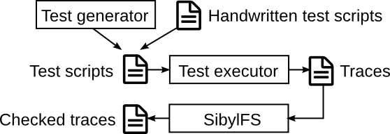

- *Test scripts* mostly generated automatically, with additional hand-written scripts
- Test scripts are fed to a *test executor* which executes the scripts on a real-world libc+OS+filesystem stack
- Results are recorded as *traces*
- Traces are checked by SibylFS (the spec) to determine whether they represent allowable behaviour or not; the output is in the form of a *checked trace*

# Example test script

A test script is essentially a list of libc calls to execute on a real-world system

```
 @type script
 #####################################
 # Test link___link_nonempty_dir1__d2__sl_dotdot_d2___nonempty_dir1__nonexist_4
 #####################################
 mkdir "empty_dir1" 0o777
 mkdir "empty_dir2" 0o777
 mkdir "nonempty_dir1" 0o777
 mkdir "nonempty_dir1/d2" 0o777
 open "nonempty_dir1/d2/f3.txt" [O_CREAT;O_WRONLY] 0o666
 write! (FD 3) "Lorem ipsum dolor sit amet, consectetur adipisicing elit, sed do eiusmod tempor inc" 83
 close (FD 3)
 ... // further setup commands
 link "nonempty_dir1/d2/sl_dotdot_d2" "nonempty_dir1/nonexist_4"
 ...
```

# Example trace (behaviour of real-world system)

A trace records the libc calls from the test script, and the responses received from the real-world system

```
# processing file 'link___link_nonempty_dir1__d2__sl_dotdot_d2___nonempty_dir1__nonexist_4-int.trace' ...
        @type trace
        #####################################
        # Test link___link_nonempty_dir1__d2__sl_dotdot_d2___nonempty_dir1__nonexist_4
        #####################################
     5: mkdir "empty_dir1" 0o777
        Tau
        RV_none
     6: mkdir "empty_dir2" 0o777
        Tau
        RV_none
     7: mkdir "nonempty_dir1" 0o777
        Tau
        RV_none
     8: mkdir "nonempty_dir1/d2" 0o777
        Tau
        RV_none
     9: open "nonempty_dir1/d2/f3.txt" [O_CREAT;O_WRONLY] 0o666
        Tau
        RV_num(3)
    10: write! (FD 3) "Lorem ipsum dolor sit amet, consectetur adipisicing elit, sed do eiusmod tempor inc" 83
        Tau
        RV_num(83)

...

    28: link "nonempty_dir1/d2/sl_dotdot_d2" "nonempty_dir1/nonexist_4"
        Tau
        RV_none

...
```

# Example checked trace

- See e.g. here (local) or [here (online)](http://fs.dsheets.name/2015-03-15_linux_ext+hfsplus+tmpfs/html/suite/link/test/link___link_nonempty_dir1__d2__sl_dotdot_d2___nonempty_dir1__nonexist_4-int.trace/index.html)

# Testing

# Test results

We found the following sorts of bugs

- Errors (and ambiguities etc) in the specifications (including POSIX, man pages etc)
- Errors and deviations in implementations
- Errors in our spec (which we then fixed of course!)

# Test results, stats

- Trace acceptance
  - Linux: 21061 accepted by spec; 9 rejected (21070 total)
  - Mac: 21036 accepted by spec, 34 rejected (21070 total); FreeBSD similar
  - essentially no barrier to getting 100% trace acceptance
- Coverage: >98% (of the spec)
  - by way of comparison, a paper (Groce et al., 2007, "Randomized differential testing...") from NASA scientists that applied randomized testing to a model of a filesystem achieved 89% coverage

# Test results, strange behaviours

- Error codes are quite often non-POSIX
- Path resolution, particularly when a trailing slash is involved, is variable, non-POSIX
- Treatment of paths referencing symlinks, particularly when the path ends in a trailing slash, is highly variable
- Various overlay filesystems, and FUSE filesystems, mess up things like permissions
- More serious: posixovl/VFAT (posix emulation on top of VFAT) gets link count wrong when rename overwrites a file that is linked elsewhere; possible to get to a state where the filesystem contains no files, but there is no free space (space leak)
- OpenZFS on Linux 3.13.0-34 (Ubuntu Trusty): files opened with `O_APPEND` would not seek to the end of the file before `write` or `pwrite` (probably causing applications that use this functionality to fail)
- OpenZFS on OS/X: possible to execute a sequence of calls which leads to the calling process hanging using 100% CPU, unresponsive to signals; volume cannot be unmounted, machine cannot be shut down; force unmounting may cause storage device to become unusable until next system restart
- Permissions: the Linux implementation of permissions should give the same behaviour from one kernel version to the next; however, we found test scripts involving file and directory access that failed on Linux kernel 3.13 and succeeded on 3.14 which we believe is due to a buggy 3.13 implementation of permissions in edge cases

# A FreeBSD bug

- An important invariant
  - if there is an error when executing a file system function, then the state of the file system is unchanged
  - => e.g. so if I try to create a file using open and I get an error, I don't have to clear up after myself
  - this invariant appears to hold for POSIX, Linux and Mac
- https://bugs.freebsd.org/bugzilla/show_bug.cgi?id=202892 (2015-09-04!)
  - opening a file: symlink deleted, file created, error returned
  - => here, this invariant is broken on FreeBSD

# Testing summary

- Huge number of tests, mostly automatically generated; tested on a large number of stacks
- SibylFS is very efficient at checking tests
- Excellent trace acceptance and coverage figures
- In edge cases there are numerous differences between POSIX, Linux, Mac and FreeBSD; most are not very interesting, but the spec gives a complete description of them; the testing even uncovered some relatively serious bugs (which we didn't expect)
- The real result of testing is that we have confidence in the spec

# A virtuous circle

- Is our spec/ testing perfect?
- Almost certainly not, but in many ways it improves on the status quo
- And there is a virtuous circle (next page)

# A virtuous circle

[figure not shown]

# Conclusion

# Possible uses of the spec

- Documentation (formal counterpart to POSIX)
- Testing existing/new filesystems (particularly non-traditional filesystems)
- Reference specification for verified filesystem implementations
- Reference model (e.g. for systems research - a lot of papers construct their own little models of parts of the filesystem)
- Basis for formal proof (Thomas Tuerk did some initial work on this in Isabelle/HOL) e.g. of properties of filesystems, or as a basis for soundness proofs of program logics etc.
- To provide a POSIX compatiblity layer e.g. on Windows, or non-traditional settings such as Mirage
- For analysis of applications: e.g. do any applications use libc calls in edge cases where the behaviour of Linux and Mac differs?
- For analysis of filesystems: e.g. do Linux and Mac behave the same when restricted to some subset of libc?
- To identify gaps in existing test suites
- etc

# Future work

Lots of possibilities. In the short term, we hope for take-up from industry.

We are currently working on **a verified file system implementation**. Compared to existing file systems, we hope for:

- better performance
- more features and functionality
- verified correctness

# Thanks for listening. Any questions?

[figure not shown]